# Capstone Quiz I

Complete all **Exercises**, and submit answers to **Questions** on the Coursera platform.

This initial quiz will concern exploratory data analysis (EDA) of the Ames Housing dataset. EDA is essential when working with any source of data and helps inform modeling.

First, let us load the data:

```r
load("ames_train.Rdata")
library(dplyr)
```

1. Which of the following are the three variables with the highest number of missing observations?
   1. `Misc.Feature`, `Fence`, `Pool.QC`
   2. `Misc.Feature`, `Alley`, `Pool.QC`
   3. `Pool.QC`, `Alley`, `Fence`
   4. `Fireplace.Qu`, `Pool.QC`, `Lot.Frontage`

```r
length(ames_train$Misc.Feature[is.na(ames_train$Misc.Feature)])
```

```
## [1] 971
```

```r
length(ames_train$Fence[is.na(ames_train$Fence)])
```

```
## [1] 798
```

```r
length(ames_train$Alley[is.na(ames_train$Alley)])
```

```
## [1] 933
```

```r
length(ames_train$Pool.QC[is.na(ames_train$Pool.QC)])
```

```
## [1] 997
```

```r
length(ames_train$Fireplace.Qu[is.na(ames_train$Fireplace.Qu)])
```

```
## [1] 491
```

```r
length(ames_train$Lot.Frontage[is.na(ames_train$Lot.Frontage)])
```

```
## [1] 167
```

2. How many categorical variables are coded in R as having type `int`? Change them to factors when conducting your analysis.
   1. 0
   2. 1
   3. 2
   4. 3

```r
ames_train$PID <- as.factor(ames_train$PID)
ames_train$MS.SubClass <- as.factor(ames_train$MS.SubClass)
```

3. In terms of price, which neighborhood has the highest standard deviation?
   1. `StoneBr`
   2. `Timber`
   3. `Veenker`
   4. `NridgHt`

```r
ames_train %>% filter(Neighborhood == "StoneBr" | Neighborhood == "Timber" | Neighborhood == "Veenker" | Neighborhood == "NridgHt") %>% group_by(Neighborhood) %>% summarise(sd(price))
```

```
## # A tibble: 4 × 2
##   Neighborhood `sd(price)`
##         <fctr>       <dbl>
## 1      NridgHt   105088.90
## 2      StoneBr   123459.10
## 3       Timber    84029.57
## 4      Veenker    72545.41
```

4. Using scatter plots or other graphical displays, which of the following variables appears to be the best single predictor of `price`?
   1. `Lot.Area`
   2. `Bedroom.AbvGr`
   3. `Overall.Qual`
   4. `Year.Built`

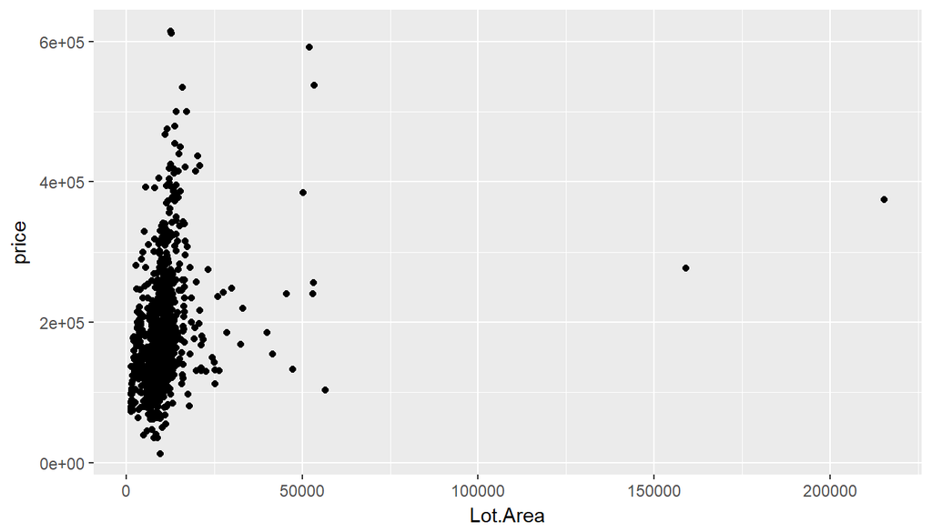

```r
library(ggplot2)
ggplot(data = ames_train, aes(Lot.Area, price)) + geom_point()
```

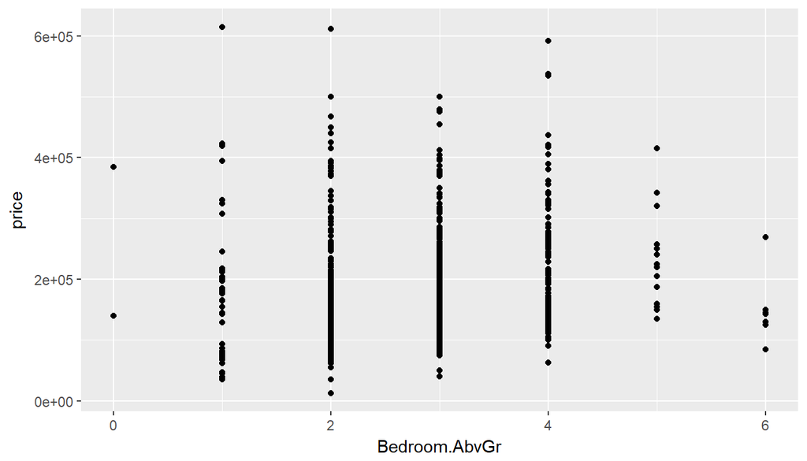

```r
ggplot(data = ames_train, aes(Bedroom.AbvGr, price)) + geom_point()
```

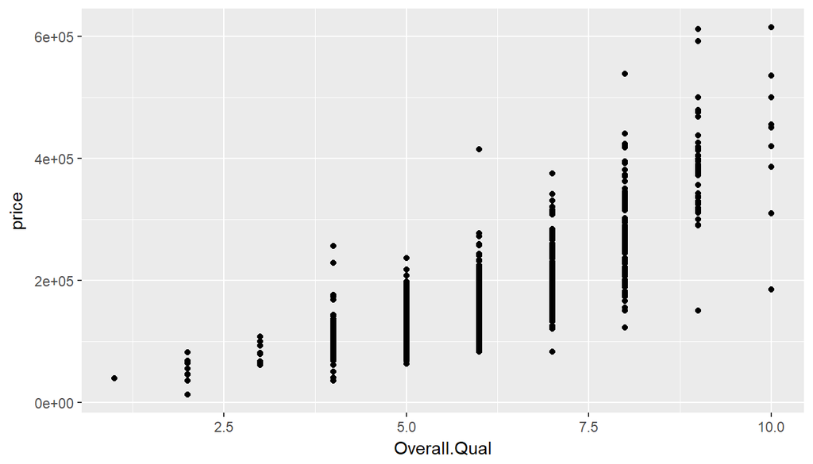

```r
ggplot(data = ames_train, aes(Overall.Qual, price)) + geom_point()
```

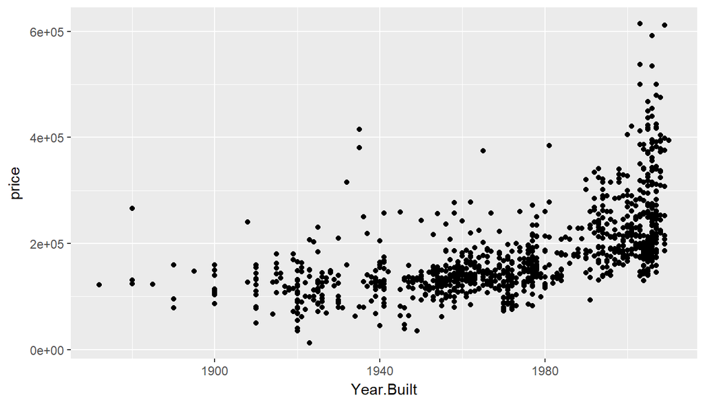

```r
ggplot(data = ames_train, aes(Year.Built, price)) + geom_point()
```

5. Suppose you are examining the relationship between `price` and `area`. Which of the following variable transformations makes the relationship appear to be the most linear?
   1. Do not transform either `price` or `area`
   2. Log-transform `price` but not `area`
   3. Log-transform `area` but not `price`
   4. Log-transform both `price` and `area`

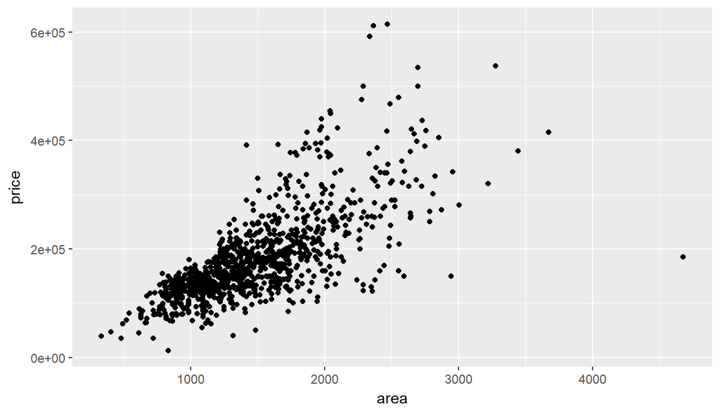

```r
ggplot(data = ames_train, aes(area, price)) + geom_point()
```

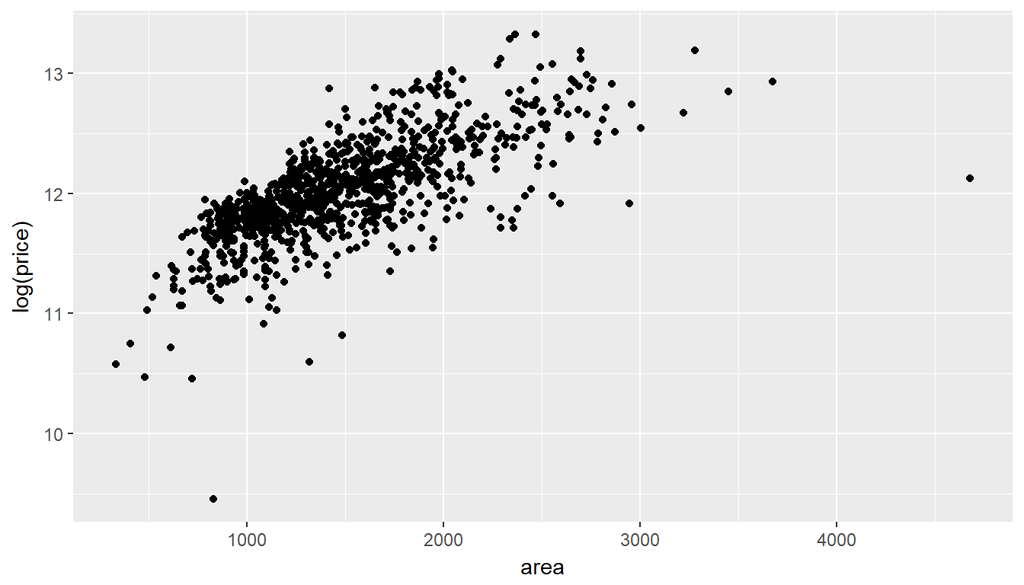

```r
ggplot(data = ames_train, aes(area, log(price))) + geom_point()
```

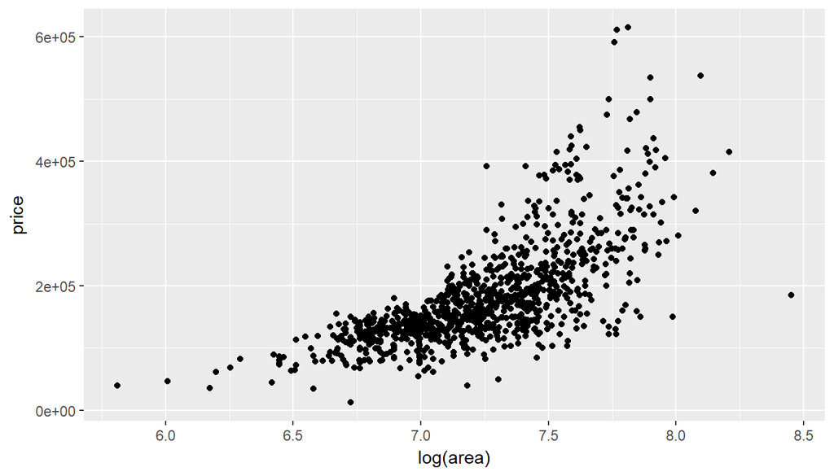

```r
ggplot(data = ames_train, aes(log(area), price)) + geom_point()
```

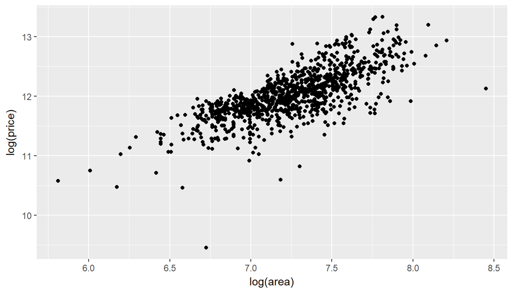

```r
ggplot(data = ames_train, aes(log(area), log(price))) + geom_point()
```

6. Suppose that your prior for the proportion of houses that have at least one garage is Beta(9, 1). What is your posterior? Assume a beta-binomial model for this proportion.
   1. Beta(954, 46)
   2. Beta(963, 46)
   3. Beta(954, 47)
   4. Beta(963, 47)

```r
ames_train %>% group_by(Garage.Cars) %>% summarise(n())
```

```
## # A tibble: 7 × 2
##   Garage.Cars `n()`
##         <int> <int>
## 1           0    46
## 2           1   288
## 3           2   526
## 4           3   132
## 5           4     6
## 6           5     1
## 7          NA     1
```

```r
length(ames_train$Garage.Cars[ames_train$Garage.Cars>0]) + 9
```

```
## [1] 963
```

```r
1 +length(ames_train$Garage.Cars[!is.na(ames_train$Garage.Cars)]) - length(ames_train$Garage.Cars[ames_train$Garage.Cars>0])
```

```
## [1] 46
```

7. Which of the following statements is true about the dataset?
   1. Over 30 percent of houses were built after the year 1999.
   2. The median housing price is greater than the mean housing price.
   3. 21 houses do not have a basement.
   4. 4 houses are located on gravel streets.

```r
length(ames_train$Year.Built[ames_train$Year.Built>1999]) / length(ames_train$Year.Built[!is.na(ames_train$Year.Built)])
```

```
## [1] 0.272
```

```r
ames_train %>% filter(!is.na(price)) %>% summarise(median(price), mean(price))
```

```
## # A tibble: 1 × 2
##   `median(price)` `mean(price)`
##             <dbl>         <dbl>
## 1          159467      181190.1
```

```r
length(ames_train$Bsmt.Qual[is.na(ames_train$Bsmt.Qual)])
```

```
## [1] 21
```

```r
ames_train %>% group_by(Street) %>% summarise(n())
```

```
## # A tibble: 2 × 2
##   Street `n()`
##   <fctr> <int>
## 1   Grvl     3
## 2   Pave   997
```

8. Test, at the $\alpha = 0.05$ level, whether homes with a garage have larger square footage than those without a garage.
   1. With a p-value near 0.000, we reject the null hypothesis of no difference.
   2. With a p-value of approximately 0.032, we reject the null hypothesis of no difference.
   3. With a p-value of approximately 0.135, we fail to reject the null hypothesis of no difference.
   4. With a p-value of approximately 0.343, we fail to reject the null hypothesis of no difference.

```r
ames_train$Garage.Dummy[ames_train$Garage.Cars>0] <- "Garage"
ames_train$Garage.Dummy[ames_train$Garage.Cars==0] <- "No Garage"

h.test.set <- ames_train %>% filter(!is.na(Garage.Dummy))
h.test.set$Garage.Dummy <- as.factor(h.test.set$Garage.Dummy)
t.test(h.test.set$area ~ h.test.set$Garage.Dummy)
```

```
##
##  Welch Two Sample t-test
##
## data:  h.test.set$area by h.test.set$Garage.Dummy
## t = 5.134, df = 50.702, p-value = 4.535e-06
## alternative hypothesis: true difference in means is not equal to 0
## 95 percent confidence interval:
##  211.4183 482.9963
## sample estimates:
##    mean in group Garage mean in group No Garage
##                1492.251                1145.043
```

9. For homes with square footage greater than 2000, assume that the number of bedrooms above ground follows a Poisson distribution with rate $\lambda$. Your prior on $\lambda$ follows a Gamma distribution with mean 3 and standard deviation 1. What is your posterior mean and standard deviation for the average number of bedrooms in houses with square footage greater than 2000 square feet?
   1. Mean: 3.61, SD: 0.11
   2. Mean: 3.62, SD: 0.16
   3. Mean: 3.63, SD: 0.09
   4. Mean: 3.63, SD: 0.91

```r
ames_train %>% filter(area > 2000) %>% summarise(sum(Bedroom.AbvGr), n())
```

```
## # A tibble: 1 × 2
##   `sum(Bedroom.AbvGr)` `n()`
##                  <int> <int>
## 1                  501   138
```

```r
(3 + 3.630435) / 138
```

```
## [1] 0.04804663
```

10. When regressing $\log$(`price`) on $\log$(`area`), there are some outliers. Which of the following do the three most outlying points have in common?
    1. They had abnormal sale conditions.
    2. They have only two bedrooms.
    3. They have an overall quality of less than 3.
    4. They were built before 1930.

```r
ames_train$Sale.Condition.Dummy[ames_train$Sale.Condition == "Abnorml"] <- 1
ames_train$Sale.Condition.Dummy[ames_train$Sale.Condition != "Abnorml"] <- 0
ames_train$Year.Built.Dummy[ames_train$Year.Built < 1930] <- 1
ames_train$Year.Built.Dummy[ames_train$Year.Built >= 1930] <- 0
ames_train$Overall.Qual.Dummy[ames_train$Overall.Qual < 3] <- 1
ames_train$Overall.Qual.Dummy[ames_train$Overall.Qual >= 3] <- 0
ames_train$Bedroom.AbvGr.Dummy[ames_train$Bedroom.AbvGr == 2] <- 1
```

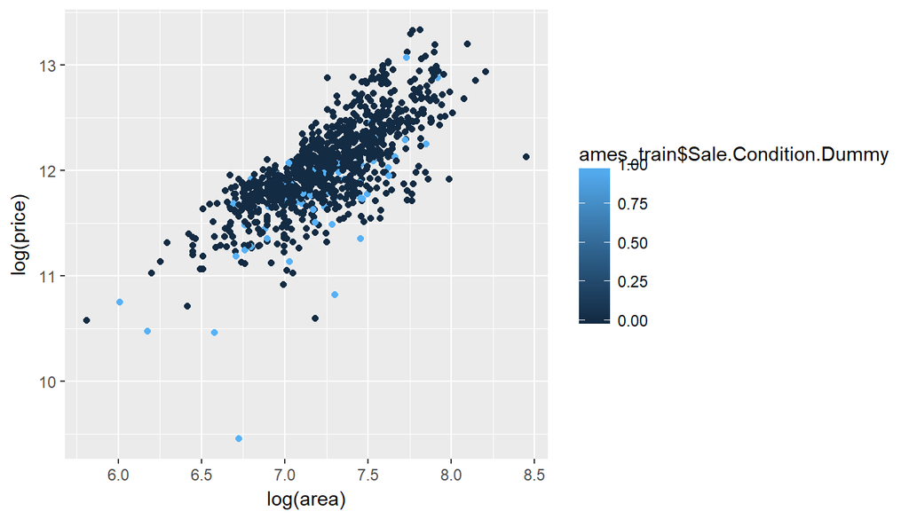

```r
ames_train$Bedroom.AbvGr.Dummy[ames_train$Bedroom.AbvGr != 2] <- 0
ggplot(data = ames_train, aes(log(area), log(price))) + geom_point(aes(colour=ames_train$Sale.Condition.Dummy, group=ames_train$Sale.Condition.Dummy))
```

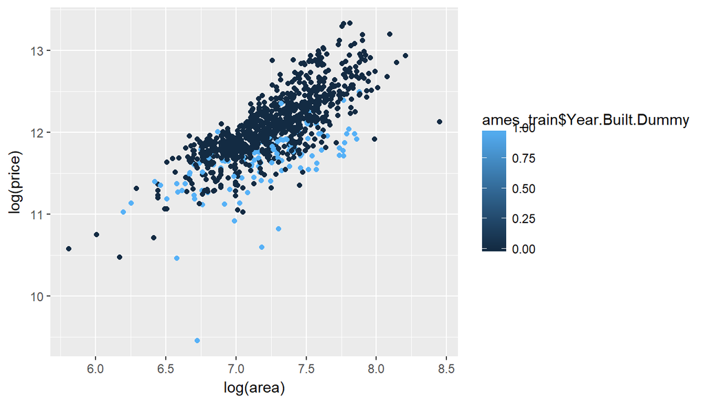

```r
ggplot(data = ames_train, aes(log(area), log(price))) + geom_point(aes(colour=ames_train$Year.Built.Dummy, group=ames_train$Year.Built.Dummy))
```

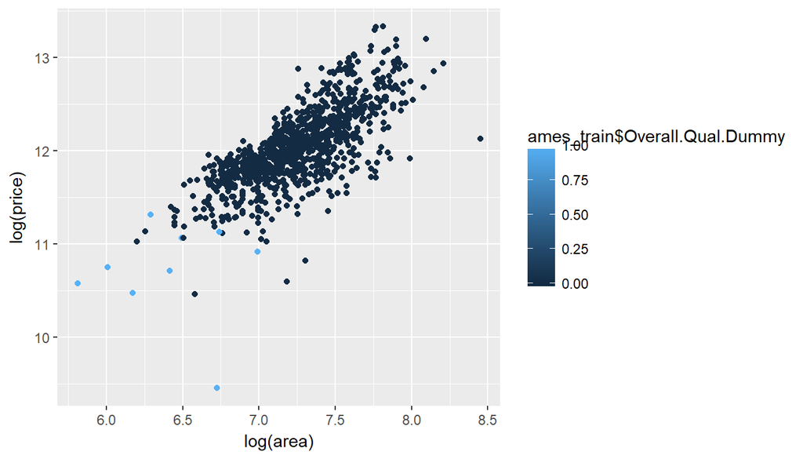

```r
ggplot(data = ames_train, aes(log(area), log(price))) + geom_point(aes(colour=ames_train$Overall.Qual.Dummy, group=ames_train$Overall.Qual.Dummy))
```

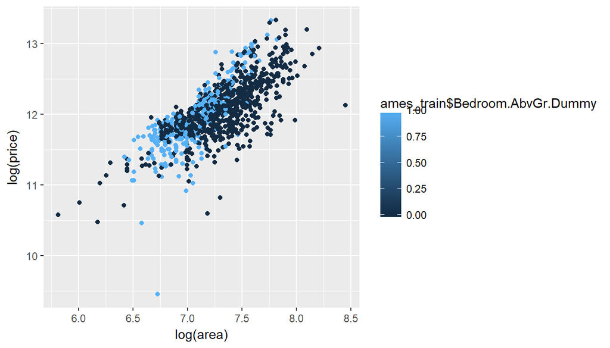

```r
ggplot(data = ames_train, aes(log(area), log(price))) + geom_point(aes(colour=ames_train$Bedroom.AbvGr.Dummy, group = ames_train$Bedroom.AbvGr.Dummy))
```

11. Which of the following are reasons to log-transform `price` if used as a dependent variable in a linear regression?
    1. `price` is right-skewed.
    2. `price` cannot take on negative values.
    3. `price` can only take on integer values.
    4. Both a and b.

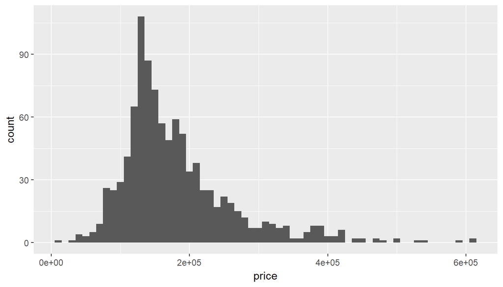

```r
ggplot(data = ames_train, aes(price)) + geom_histogram(binwidth = 10000)
```

12. How many neighborhoods consist of only single-family homes? (e.g. `Bldg.Type` = `1Fam`)
    1. 0
    2. 1
    3. 2
    4. 3

```r
ames_train %>% group_by(Neighborhood) %>% summarise(val = length(Bldg.Type[Bldg.Type=="1Fam"])/length(Bldg.Type)) %>% filter(val==1)
```

```
## # A tibble: 3 × 2
##   Neighborhood   val
##         <fctr> <dbl>
## 1      ClearCr     1
## 2      NoRidge     1
## 3       Timber     1
```

13. Using color, different plotting symbols, conditioning plots, etc., does there appear to be an association between $\log$(`area`) and the number of bedrooms above ground (`Bedroom.AbvGr`)?
    1. Yes
    2. No

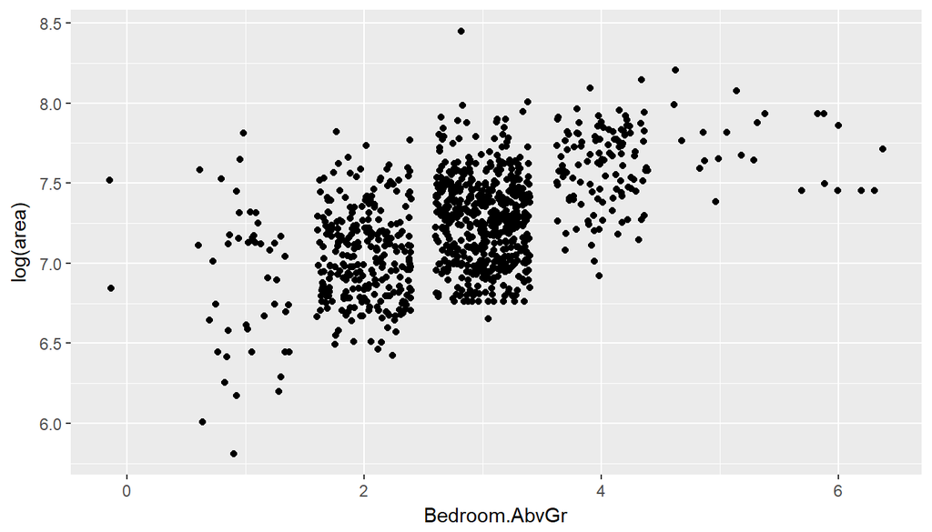

```r
ggplot(data=ames_train, aes(Bedroom.AbvGr, log(area))) + geom_jitter()
```

14. Of the people who have unfinished basements, what is the average square footage of the unfinished basement?
    1. 590.36
    2. 595.25
    3. 614.37
    4. 681.94

```r
ames_train %>% filter(Bsmt.Unf.SF>0) %>% summarise(mean(Bsmt.Unf.SF))
```

```
## # A tibble: 1 × 1
##   `mean(Bsmt.Unf.SF)`
##                 <dbl>
## 1            595.2527
```